# Лабораторная работа №4

Операционнные системы

Мустафина А.Ю. НКАбд-03-24

Российский университет дружбы народов, Москва, Россия

8 марта 2025

## Цель работы

Получение навыков правильной работы с репозиториями git.

## Задание

- Выполнить работу для тестового репозитория.
- Преобразовать рабочий репозиторий в репозиторий с git-flow и conventional commits.

# Теоретическое введение

### Общая информация

- Gitflow Workflow опубликована и популяризована Винсентом Дриссеном.
- Gitflow Workflow предполагает выстраивание строгой модели ветвления с учётом выпуска проекта.
- Данная модель отлично подходит для организации рабочего процесса на основе релизов.
- Работа по модели Gitflow включает создание отдельной ветки для исправлений ошибок в рабочей среде.
- Последовательность действий при работе по модели Gitflow:
  - Из ветки master создаётся ветка develop.
  - Из ветки develop создаётся ветка release.
  - Из ветки develop создаются ветки feature.
  - Когда работа над веткой feature завершена, она сливается с веткой develop.
  - Когда работа над веткой релиза release завершена, она сливается в ветки develop и master.
  - Если в master обнаружена проблема, из master создаётся ветка hotfix.
  - Когда работа над веткой исправления hotfix завершена, она сливается в ветки develop и master.

# Выполнение лабораторной работы

## Установка программного обеспечения

Устанавливаю git-flow (рис. 1).

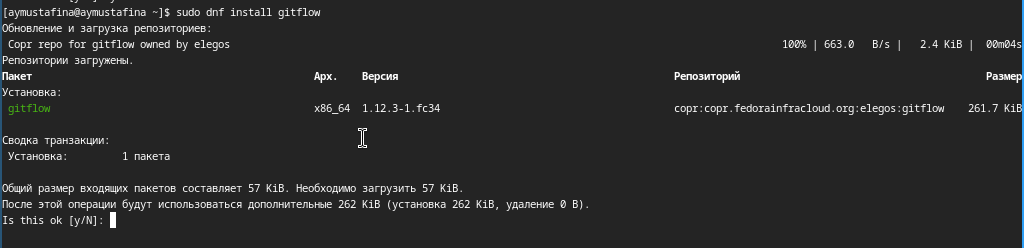

Установка git-flow

## Установка программного обеспечения

Устанавливаю Node.js На Node.js базируется программное обеспечение для семантического версионирования и общепринятых коммитов(рис. 2).

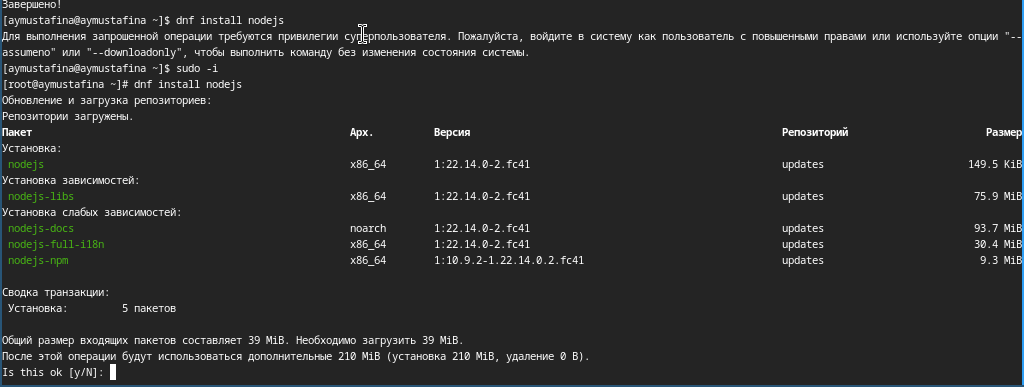

Установка Node.js

## Установка программного обеспечения

Устанавливаю pnpm (рис. 3).

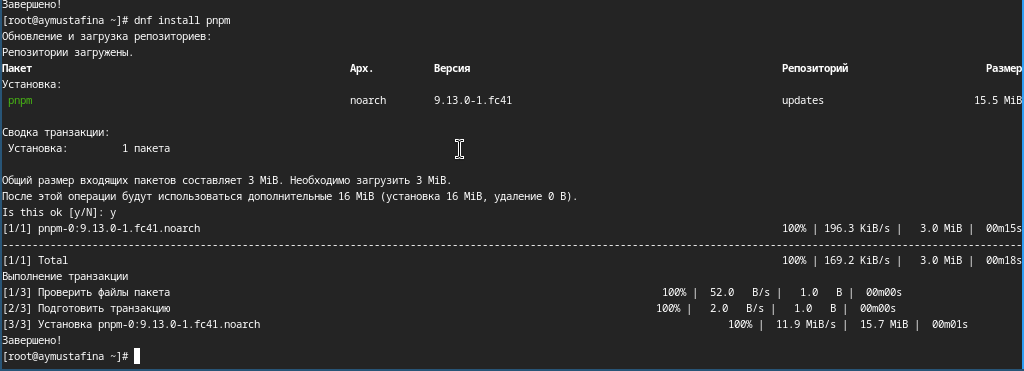

Установка pnpm

## Установка программного обеспечения

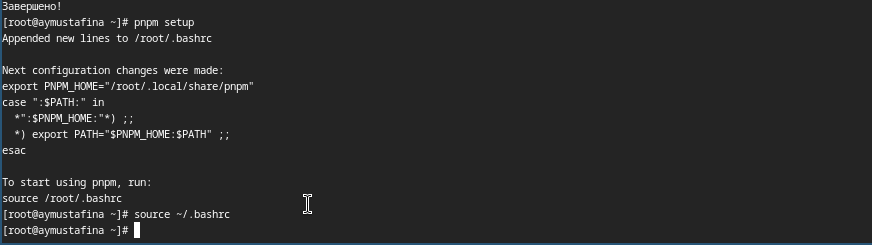

Настройка

## Установка программного обеспечения

Устанавливаю commitizen(рис. 5).

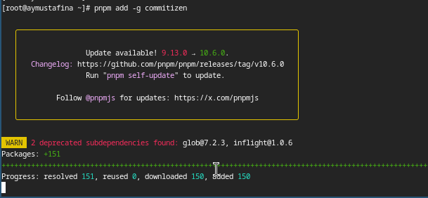

Установка commitizen

## Установка программного обеспечения

Устанавливаю standard-changelog(рис. 6).

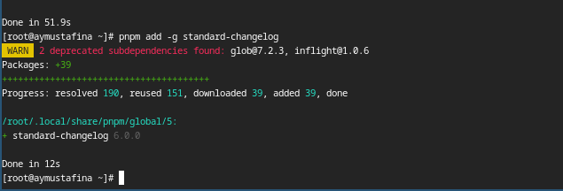

Установка standard-changelog

## Практический сценарий использования Git

Создаю новый репозиторий на github, называю его git-extended(рис. 7).

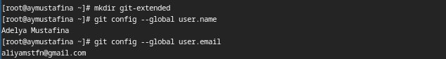

Создание репозитория

## Практический сценарий использования Git

Делаю первый коммит (рис. 8).

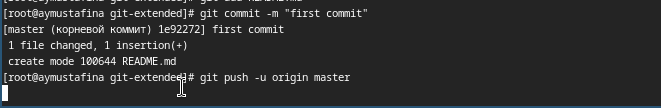

Первый коммит

## Практический сценарий использования Git

Выкладываю его на github (рис. 9).

[figure not shown]

Выкладываю

## Практический сценарий использования Git

Конфигурация для пакетов Node.js (рис. 10).

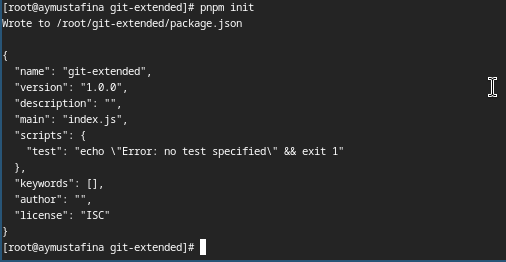

Конфигурация

## Практический сценарий использования Git

Открываю в редакторе и заполняю несколько параметров пакета. Таким образом, файл package.json приобретает вид:

```
{
    "name": "git-extended",
    "version": "1.0.0",
    "description": "Git repo for educational purposes",
    "main": "index.js",
    "repository": "git@github.com:username/git-extended.git",
    "author": "Name Surname <username@gmail.com>",
    "license": "CC-BY-4.0",
    "config": {
        "commitizen": {
            "path": "cz-conventional-changelog"
        }
    }
}
```

## Практический сценарий использования Git

Вид (рис. 11).

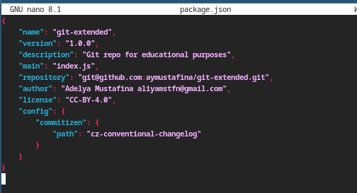

Файл package.json

## Практический сценарий использования Git

Добавляю новые файлы. Выполняю коммит (рис. 12).

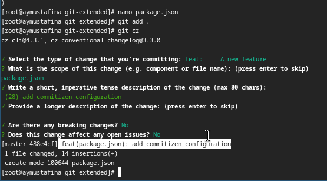

Коммит

## Практический сценарий использования Git

Отправляю все на github (рис. 13).

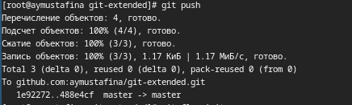

Отправка

## Практический сценарий использования Git

Инициализирую git-flow, префикс для ярлыков устанавливаю в v. Проверяю, что я на ветке develop. Загружаю все в хранилище (рис. 14).

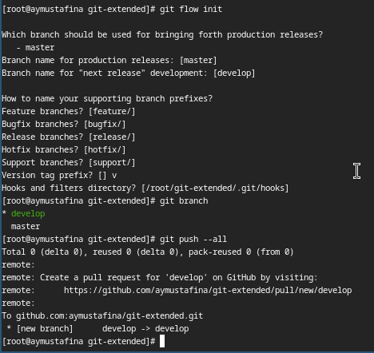

Иницаиализация

## Практический сценарий использования Git

Устанавливаю внешнюю ветку как вышестоящую для этой ветки и создаю релиз с версией 1.0.0 (рис. 15).

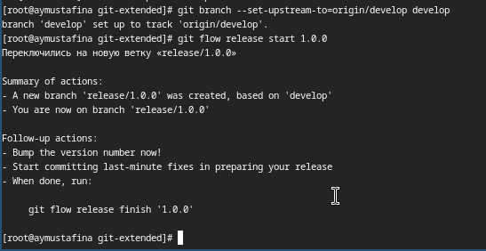

Релиз 1.0.0

## Практический сценарий использования Git

Создаю журнал изменений standard-changelog –first-release (рис. 16).

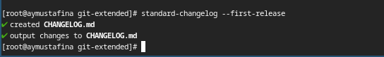

Журнал изменений

## Практический сценарий использования Git

Добавляю журнал изменений в индекс (рис. 17).

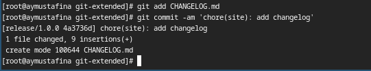

Журнал изменений в индекс

## Практический сценарий использования Git

Заливаю релизную ветку в основную ветку (рис. 18).

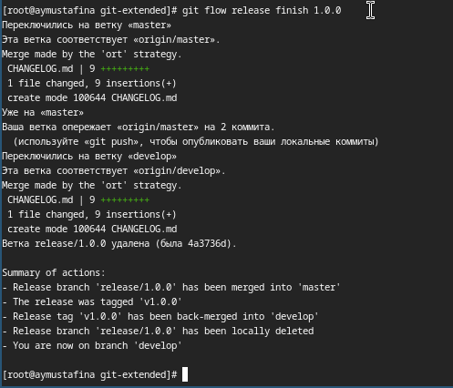

Релизная в основную

## Практический сценарий использования Git

Отправляю данные на github и создаю релиз (рис. 19).

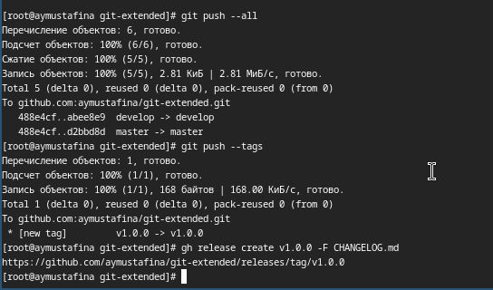

Отправка и релиз

## Работа с репозиторием git

Создаю ветку для новой функциональности и по окончании работы с git объединяю ветку feature_branch c develop (рис. 20).

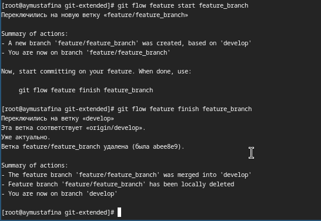

Создание и объединение веток

## Работа с репозиторием git

Создаю релиз с версией 1.2.3, в файле обновляю ее номер (рис. 21).

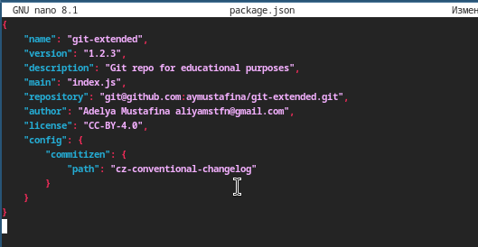

Релиз 1.2.3

## Работа с репозиторием git

Создаю журнал изменений (рис. 22).

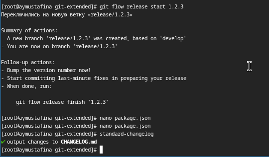

Журнал изменений

## Работа с репозиторием git

Добавляю журнал изменений в индекс и заливаю релизную ветку в основную (рис. 23).

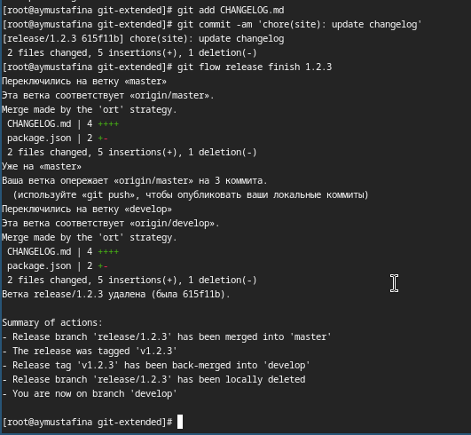

Журнал в индекс

## Работа с репозиторием git

Отправляю данные на гитхаб и создаю релиз с комментарием из журнала изменений (рис. 24).

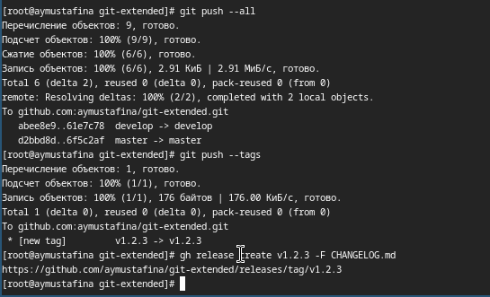

Отправка

# Выводы

Я научилась работать с релизами в Github, узнала больше о типах и структуре коммитов.